# Exploratory Data Analysis

Heart Disease

Rhowena Vespa  
1/16/2022

### INTRODUCTION

According to the CDC, heart disease is the leading cause of death in the US, followed by cancer and Covid-19 in 2020. This research involves analysis of Heart Disease using the “Stroke Prediction Dataset” from Kaggle. The dataset has 5110 observations consisting of binary and continuous variables of risk factors for heart disease such as hypertension, obesity, diabetes, and smoking among others. Using the data set, this research aims to establish correlations between the prevalence of the different risk factors in patients who have heart disease. The CDC also states that adults age 45-54 have the highest prevalence of obesity (38.1%) while adults age 18-24 have the lowest prevalence (19.5%) in the US. I would like to compare this information with this data set.

### RESEARCH QUESTIONS

1. Assessment of prevalence of risk factors in patients with heart disease.

```
  A. How many patients with heart disease ALSO have hypertension?

  B. How many patients with heart disease ALSO have stroke?
```

2. According to the CDC, about 14% (34 million) US adults are smokers.

```
  A. How many patients with heart disease continue smoking?
```

3. Are older patients more likely to have obesity or have diabetes?

## DATA

1. Read CSV file into R

```r
library(distill)
library(dplyr)
library(readr)
library(tidyverse)
library(knitr)
HeartDisease<- read.csv('healthcare-dataset-stroke-data.csv',TRUE,',',na.strings = "N/A")
class(HeartDisease)
```

```
[1] "data.frame"
```

```r
colnames(HeartDisease)
```

```
 [1] "id"                "gender"            "age"
 [4] "hypertension"      "heart_disease"     "ever_married"
 [7] "work_type"         "Residence_type"    "avg_glucose_level"
[10] "bmi"               "smoking_status"    "stroke"
```

```r
dim(HeartDisease)
```

```
[1] 5110   12
```

The dataset consisted of patients from infant (age=0) to age 82. This research will focus on the prevalence of risk factors on ADULT patients with heart disease. The dataset will first be filtered to exclude data on children (age < 18) and patient ID. The binary variables that have values of 1 =yes and 0=No are hypertension, heart disease and stroke; gender is “male” or “female”, ever married is “yes” or “no”, residence type is “urban” or “rural”. Other categorical variables are work type and smoking status, Numerical variables are age, body mass index (bmi) and avg glucose levels.

```r
AdultHD<- filter(HeartDisease, age>=18) #Filter out children age 0-17
AdultHD1<-select(AdultHD,-c(id))  #drop the patient id column 'id'
kable(head(AdultHD1), format = "markdown", digits = 2)
```

| gender | age | hypertension | heart_disease | ever_married | work_type | Residence_type | avg_glucose_level | bmi | smoking_status | stroke |
| --- | --- | --- | --- | --- | --- | --- | --- | --- | --- | --- |
| Male | 67 | 0 | 1 | Yes | Private | Urban | 228.69 | 36.6 | formerly smoked | 1 |
| Female | 61 | 0 | 0 | Yes | Self-employed | Rural | 202.21 | NA | never smoked | 1 |
| Male | 80 | 0 | 1 | Yes | Private | Rural | 105.92 | 32.5 | never smoked | 1 |
| Female | 49 | 0 | 0 | Yes | Private | Urban | 171.23 | 34.4 | smokes | 1 |
| Female | 79 | 1 | 0 | Yes | Self-employed | Rural | 174.12 | 24.0 | never smoked | 1 |
| Male | 81 | 0 | 0 | Yes | Private | Urban | 186.21 | 29.0 | formerly smoked | 1 |

## DATA VISUALIZATION

```r
HD<-mutate(AdultHD1, heart_disease = recode(heart_disease, `1` = "Yes", `0` = "No"))
```

```r
HD %>%
  count(heart_disease, sort = TRUE) %>%
  head(4)
```

```
  heart_disease    n
1            No 3979
2           Yes  275
```

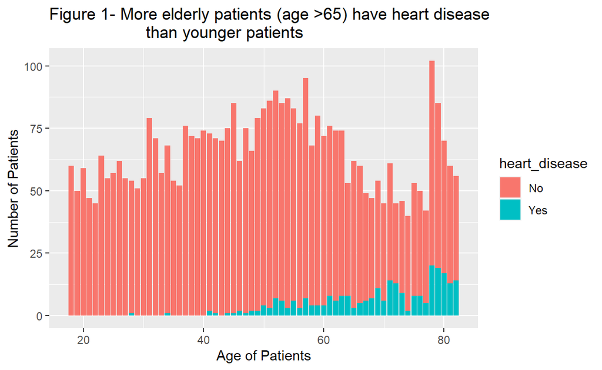

```r
ggplot(HD, aes(x=age, fill=heart_disease))+
  geom_bar() +
  labs(x="Age of Patients", y="Number of Patients",
  title = "Figure 1- More elderly patients (age >65) have heart disease
                    than younger patients")
```

EXPLANATION: Used geom_bar to show distribution of growing age with heart disease compared with no heart disease.